# Linear modelling on Friends TV Show data from Kraggle

Harry Lyness

18/07/2022

# Introduction

This is a non-academic project I started because I was curious about applications of linear modelling. So I thought, why not apply linear modelling to my favorite show on Netflix, FRIENDS!

# Loading In Packages and Data

Useful Packages for data analysis

```r
library(tidyverse)
library(broom)
library(patchwork)
library(lubridate)
library(gridExtra)
library(effects)
```

Since we are going to be working with linear models, I have created a `diagnostic_plots()` function to output the diagnostic plots for any linear model in a grid.

```r
diagnostic_plots = function(lmod)
{
  oldpar=par()
  par(mfrow=c(2,2),mar=c(2.6,2.6,2.1,0.1),mgp=c(1.5,0.5,0))
  plot(lmod)
}
```

Data, which has been sourced from Kraggle (https://www.kaggle.com/datasets/rezaghari/friends-series-dataset). I have chosen to work with `friends_episodes_v3.csv` because `friends_episodes_v2.csv` had a missing episode and no ‘episode number in season’ variable. Both problems could have easily been fixed with the original data, but to save time and computations, I may as well use the set which has been cleaned better.

```r
friends = read_csv("friends_episodes_v3.csv")
```

Description of data,

- Year_of_prod: Year of production based on IMDB
- Season: Season of the Friends TV show from 1 to 10
- `EpisodeNumber`: The episode number in the particular season
- Episode_Title: The title of each episode in each season
- Duration: Duration of each episode in minutes
- Summary: Summary of the episode in a few lines
- Director: Director of the specific episode
- Stars: IMDB rating of the episode
- Votes: Total number of votes on IMDB by the date of publishing this data set

Set up index variable for subsequent analysis, which is the number of each episode in time order from 1 to 236.

```r
friends$index = seq_along(friends$Year_of_prod)
```

# Cleaning data

View our data set. Summary command is useful to spot any immediate problems with the data.

```r
view(friends)
summary(friends)
```

```
##   Year_of_prod      Season       Episode Number  Episode_Title
##  Min.   :1994   Min.   : 1.000   Min.   : 1.00   Length:236
##  1st Qu.:1997   1st Qu.: 3.000   1st Qu.: 6.00   Class :character
##  Median :1999   Median : 5.000   Median :12.00   Mode  :character
##  Mean   :1999   Mean   : 5.377   Mean   :12.38
##  3rd Qu.:2001   3rd Qu.: 8.000   3rd Qu.:18.00
##  Max.   :2004   Max.   :10.000   Max.   :25.00
##     Duration       Summary            Director             Stars
##  Min.   :22.00   Length:236         Length:236         Min.   :7.200
##  1st Qu.:22.00   Class :character   Class :character   1st Qu.:8.200
##  Median :22.00   Mode  :character   Mode  :character   Median :8.400
##  Mean   :22.34                                         Mean   :8.459
##  3rd Qu.:22.00                                         3rd Qu.:8.700
##  Max.   :30.00                                         Max.   :9.700
##      Votes           index
##  Min.   : 2557   Min.   :  1.00
##  1st Qu.: 2887   1st Qu.: 59.75
##  Median : 3148   Median :118.50
##  Mean   : 3370   Mean   :118.50
##  3rd Qu.: 3584   3rd Qu.:177.25
##  Max.   :10381   Max.   :236.00
```

We notice that `Director`, `Episode_Title` and `Summary`(episode plot) are in the incorrect format. The `Season` summary is not useful since we do not care about the mean of seasons… So, I changed the format of the ‘Season’ variable to show how many episodes are in each season.

```r
friends$Director <- as.factor(friends$Director)
friends$Season <- as.factor(friends$Season)
friends$Episode_Title = as.factor(friends$Episode_Title)
friends$Summary = as.factor(friends$Summary)
summary(friends)
```

```
##   Year_of_prod      Season   Episode Number                       Episode_Title
##  Min.   :1994   3      :25   Min.   : 1.00   The One in Barbados         :  2
##  1st Qu.:1997   6      :25   1st Qu.: 6.00   The One That Could Have Been:  2
##  Median :1999   1      :24   Median :12.00   The One with Ross's Wedding :  2
##  Mean   :1999   2      :24   Mean   :12.38   The One with the Proposal   :  2
##  3rd Qu.:2001   4      :24   3rd Qu.:18.00   The Last One: Part 1        :  1
##  Max.   :2004   5      :24   Max.   :25.00   The Last One: Part 2        :  1
##                 (Other):90                   (Other)                     :226
##     Duration
##  Min.   :22.00
##  1st Qu.:22.00
##  Median :22.00
##  Mean   :22.34
##  3rd Qu.:22.00
##  Max.   :30.00
##
##                                                                                                                                                                                                                                    Summary
##  A bored Ross wreaks havoc in Chandler and Joey's lives. Rachel is uncomfortable with Danny's unusually close relationship with his sister. Phoebe runs into trouble whilst collecting donations for the poor during Christmas.        :  1
##  A drunken Chandler fools around with one of Joey's sisters - but he can't remember which one. Ross becomes skeptical when a guy at the diner gets Rachel an interview for a position at Bloomingdales.                                :  1
##  A drunken Rachel calls Ross and reveals her feelings for him on his answering machine. Meanwhile, Monica keeps busy by being Chandler's personal trainer and Phoebe constantly wonders why her current boyfriend won't sleep with her.:  1
##  A humiliated Emily runs away after Ross says Rachel's name at the altar. Meanwhile, Chandler and Monica struggle to get time alone together.                                                                                          :  1
##  A night at Mike's piano bar gives Monica a very showy moment in the spotlight; Chandler employs his secret skill to repair Joey's botched eyebrow-waxing job.                                                                         :  1
##  A stressed Ross desperately and insistently tries to get the rest of the gang ready for a black tie event at the museum, while Joey and Chandler clash over personal belongings and personal space.                                   :  1
##  (Other)                                                                                                                                                                                                                               :230
##             Director      Stars           Votes           index
##  Gary Halvorson :54   Min.   :7.200   Min.   : 2557   Min.   :  1.00
##  Kevin Bright   :54   1st Qu.:8.200   1st Qu.: 2887   1st Qu.: 59.75
##  Michael Lembeck:24   Median :8.400   Median : 3148   Median :118.50
##  James Burrows  :15   Mean   :8.459   Mean   : 3370   Mean   :118.50
##  Gail Mancuso   :14   3rd Qu.:8.700   3rd Qu.: 3584   3rd Qu.:177.25
##  Peter Bonerz   :12   Max.   :9.700   Max.   :10381   Max.   :236.00
##  (Other)        :63
```

There seems to be no duplicate `Summary`’s, but there are duplicate episode titles. In order for this to not mess with my analysis, I shall rename the episodes.

```r
friends[217,4] = "The One in Barbados: Part 1"
friends[218,4] = "The One in Barbados: Part 2"

friends[136,4] = "The One That Could Have Been: Part 1"
friends[137,4] = "The One That Could Have Been: Part 2"

friends[96,4] = "The One with Ross's Wedding: Part 1"
friends[97,4] = "The One with Ross's Wedding: Part 2"

friends[145,4] = "The One with the Proposal: Part 1"
friends[146,4] = "The One with the Proposal: Part 2"
```

Checking for blank entries in data set. Since this is a small data frame, an easy way to check for `NA` values is to first sort each column; then, if there are `NA` values, they will be at the bottom of the data frame. I have included code which will calculate the number of `NA` values in each column of the `friends` data frame. This is a much more efficient way of completing the task.

```r
cbind(
   lapply(
     lapply(friends, is.na)
     , sum)
   )
```

```
##                [,1]
## Year_of_prod   0
## Season         0
## Episode Number 0
## Episode_Title  0
## Duration       0
## Summary        0
## Director       0
## Stars          0
## Votes          0
## index          0
```

I conclude that there are no blank entries in the `friends` data frame.

# Initial Analysis

Directors play a huge role in a TV Shows success. It would be a good idea to see the distribution of directors for Friends.

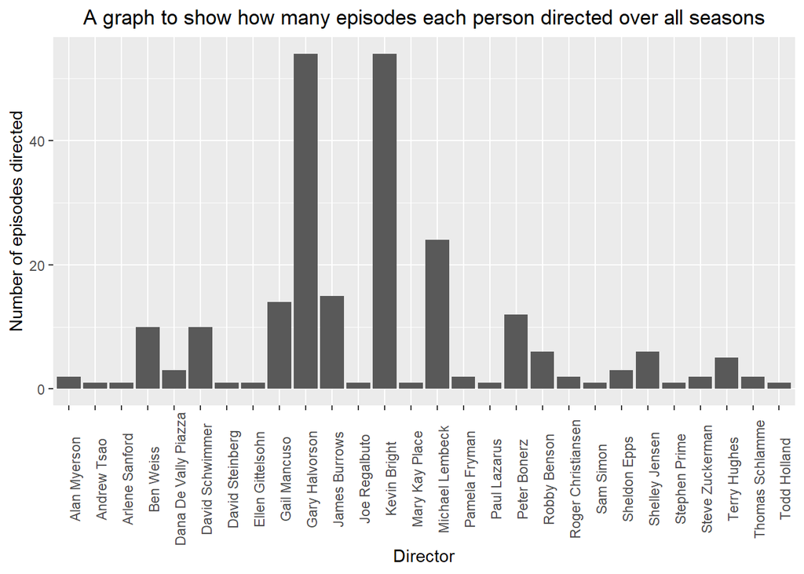

```r
BarDirector=friends %>% select(Director) %>% count(Director)
ggplot(BarDirector, aes(x=Director, y=n)) +
  geom_bar(stat = "identity")+xlab("Director")+ylab("Number of episodes directed")+theme(axis.text.x = element_text(angle = 90)) + ggtitle("A graph to show how many episodes each person directed over all seasons") + theme(plot.title = element_text(hjust = 0.5))
```

There seems to be a fair scattering on who directed a large number of episodes. This implies that there is scope to see whether the choice in director made a difference in the rating of each episode. This shall be investigated.

```r
xtabs( ~Director, friends)
```

```
## Director
##         Alan Myerson          Andrew Tsao       Arlene Sanford
##                    2                    1                    1
##            Ben Weiss Dana De Vally Piazza      David Schwimmer
##                   10                    3                   10
##      David Steinberg     Ellen Gittelsohn         Gail Mancuso
##                    1                    1                   14
##       Gary Halvorson        James Burrows        Joe Regalbuto
##                   54                   15                    1
##         Kevin Bright       Mary Kay Place      Michael Lembeck
##                   54                    1                   24
##        Pamela Fryman         Paul Lazarus         Peter Bonerz
##                    2                    1                   12
##         Robby Benson   Roger Christiansen            Sam Simon
##                    6                    2                    1
##         Sheldon Epps       Shelley Jensen        Stephen Prime
##                    3                    6                    1
##      Steve Zuckerman         Terry Hughes      Thomas Schlamme
##                    2                    5                    2
##         Todd Holland
##                    1
```

Computing some facts about each season which could have interesting analysis.

```r
# Defining variables needed for computations and new data frame 'SeasonInfo'
SeasonEpisodeNumber = c(24,24,25,24,24,25,24,24,24,18)
SeasonNumber=c(1,2,3,4,5,6,7,8,9,10)
MeanStarsSeason = SeasonNumber
MeanVotesSeason = SeasonNumber
Total_Duration = SeasonNumber

# Calculating the mean star rating and Votes of each season.
for(i in (1:10)){
  temp = friends %>% select(Stars,Season,Votes,Duration) %>% filter(Season == SeasonNumber[i])
  MeanStarsSeason[i]=mean(temp$Stars)
  MeanVotesSeason[i]=mean(temp$Votes)
  Total_Duration[i]=mean(temp$Duration)*SeasonEpisodeNumber[i]
}
# Decimal Season numbers on the x-axis would not make sense
SeasonNumber=as.character(SeasonNumber)

# Creating 'SeasonInfo' data frame
SeasonInfo = data.frame(SeasonNumber,SeasonEpisodeNumber,MeanStarsSeason,MeanVotesSeason,Total_Duration)
names(SeasonInfo)[1]='Season'
names(SeasonInfo)[2]='Number_of_episodes_in_each_season'
names(SeasonInfo)[3]='Mean_star_rating'
names(SeasonInfo)[4]='Mean_Votes'
SeasonInfo
```

```
##    Season Number_of_episodes_in_each_season Mean_star_rating Mean_Votes
## 1       1                                24         8.316667   4284.875
## 2       2                                24         8.458333   3708.917
## 3       3                                25         8.408000   3458.480
## 4       4                                24         8.475000   3393.375
## 5       5                                24         8.637500   3455.917
## 6       6                                25         8.496000   3153.080
## 7       7                                24         8.437500   2940.708
## 8       8                                24         8.445833   2983.708
## 9       9                                24         8.291667   2760.583
## 10     10                                18         8.677778   3625.778
##    Total_Duration
## 1             528
## 2             528
## 3             550
## 4             544
## 5             528
## 6             582
## 7             528
## 8             528
## 9             544
## 10            412
```

Season 3 and season 6 contained the most episodes, with season 6 having the longest total duration. Season 10 had the highest average stars rating per episode. Season 1 had the highest mean votes per episode.

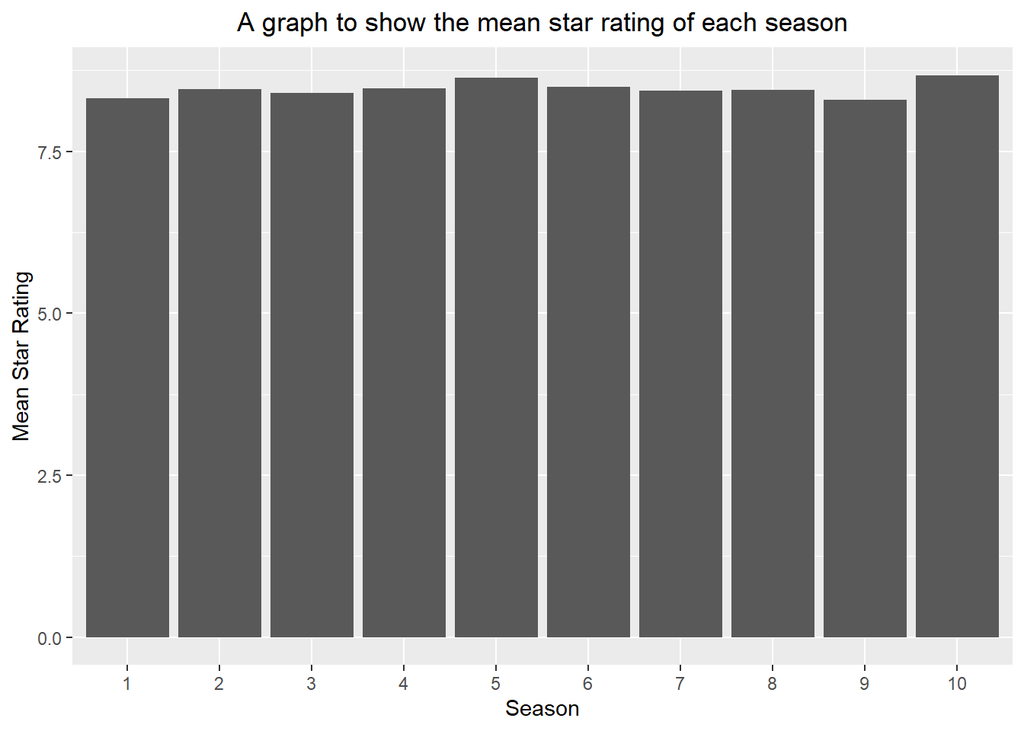

```r
# Re-Ordering seasons so that bar chart is in logical order from first to last season
SeasonInfo$Season = factor(SeasonInfo$Season, levels = c('1', '2', '3', '4', '5', '6', '7','8','9','10'))
ggplot(SeasonInfo,aes(x=Season,y=Mean_star_rating)) + geom_bar(stat = "identity") + xlab("Season")  + ylab("Mean Star Rating")+ ggtitle("A graph to show the mean star rating of each season") + theme(plot.title = element_text(hjust = 0.5))
```

This is actually very interesting. We can see that the average star rating across all seasons are approximately the same . This would suggest that the star rating did not change significantly across all seasons. This is unusual for popular TV shows as normally the star ratings tend to decrease as the show continues. This is something which is worth investigating statistically.

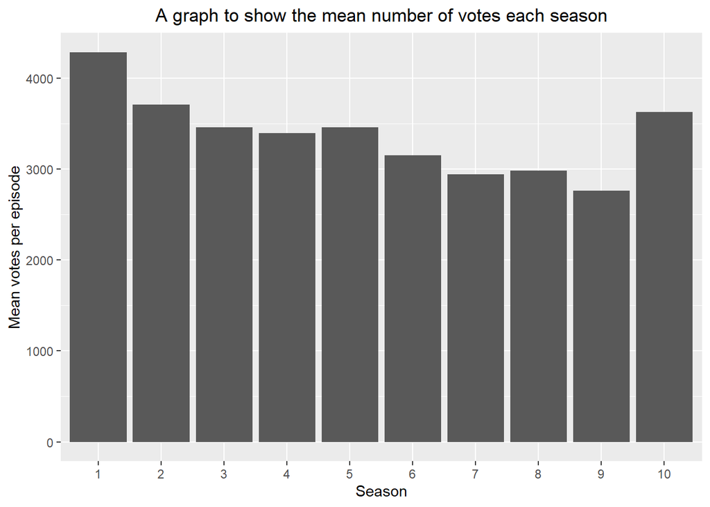

```r
ggplot(SeasonInfo,aes(x=Season,y=Mean_Votes)) + geom_bar(stat = "identity") + xlab("Season")  + ylab("Mean votes per episode") + ggtitle("A graph to show the mean number of votes each season") + theme(plot.title = element_text(hjust = 0.5))
```

The number of votes decreasing suggests that as time went on less people where watching the show. However, the people who where watching the show were still enjoying it. Season 10 does not follow the trend. This could be due to some episodes having unusually high votes within that season.

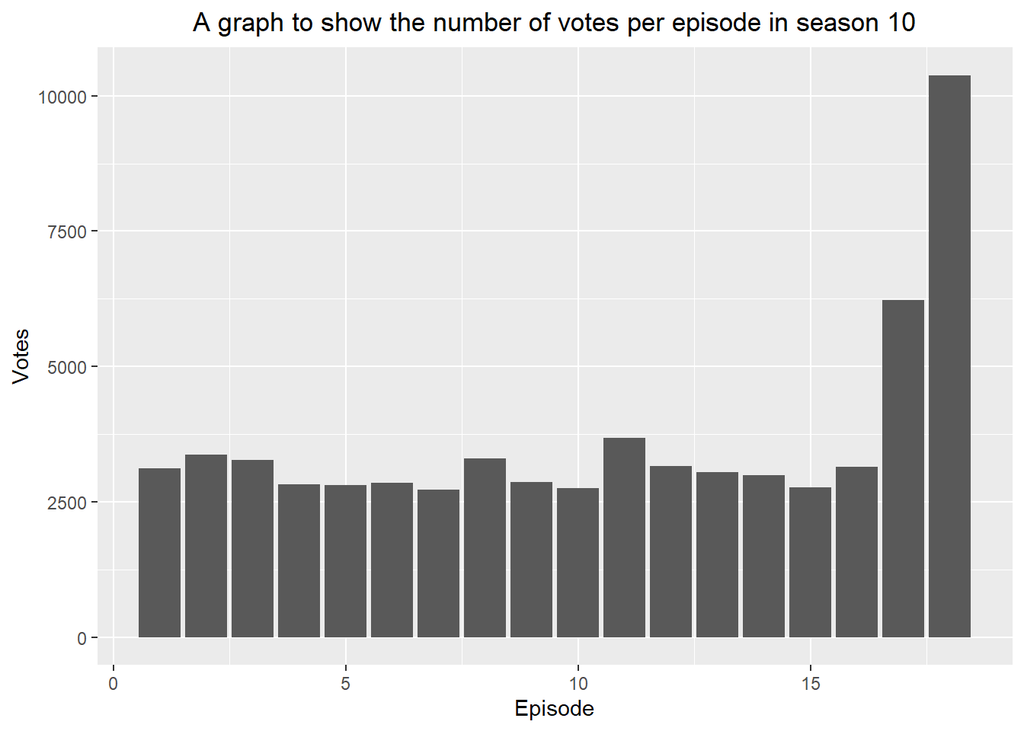

```r
Season10 = friends %>% filter(Season == 10)
ggplot(Season10,aes(x=`Episode Number`,y=Votes)) + geom_bar(stat = "identity") + xlab("Episode")  + ylab("Votes") + ggtitle("A graph to show the number of votes per episode in season 10") + theme(plot.title = element_text(hjust = 0.5))
```

The first 16 episodes of the season seem to follow the trend, looking at the mean number of votes for previous seasons. The last two episodes seem to have an unusually large number of votes. Lets see if these episodes are also have a high star rating.

```r
orderF = friends %>% select(Season,Episode_Title,Stars,Votes)
orderF[order(-orderF$Stars), ]
```

```
## # A tibble: 236 x 4
##    Season Episode_Title                       Stars Votes
##    <fct>  <fct>                               <dbl> <dbl>
##  1 5      The One Where Everybody Finds Out     9.7  8066
##  2 10     The Last One: Part 2                  9.7 10381
##  3 4      The One with the Embryos              9.5  6006
##  4 10     The Last One: Part 1                  9.5  6221
##  5 2      The One with the Prom Video           9.4  5736
##  6 6      The One with the Proposal: Part 2     9.3  4186
##  7 8      The One with the Videotape            9.3  4114
##  8 8      The One with the Rumor                9.3  5291
##  9 4      The One with Ross's Wedding: Part 2   9.2  4217
## 10 5      The One with All the Thanksgivings    9.2  4261
## # ... with 226 more rows
```

The last 2 episodes of season 10 do indeed have a large number of votes and a very high star rating. It would be interesting to investigate this further. Personally, my favourite episode is ‘The One Where Everybody Finds Out’, so I am not surprised it has the highest star rating… It is an amazing episode!

# Did the stars change significantly over time?

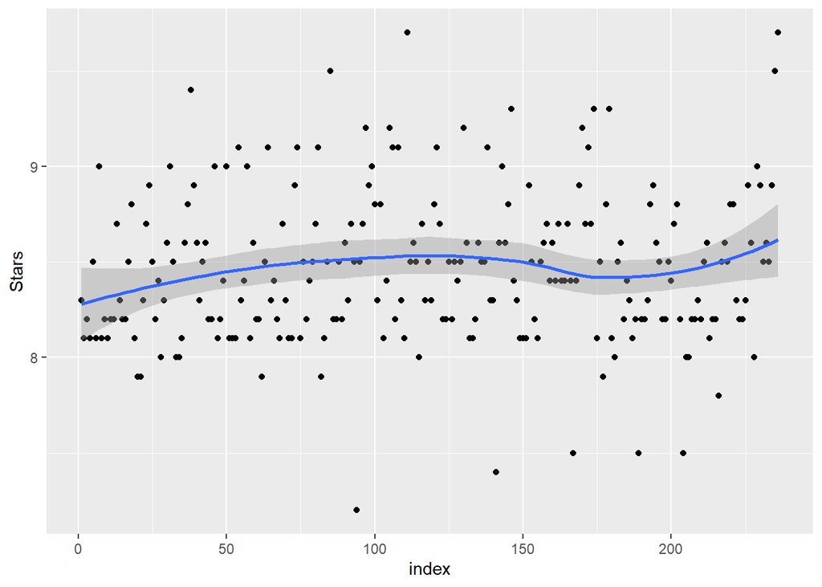

```r
ggplot(friends, aes(x = index, y = Stars)) + geom_point() + geom_smooth()
```

```r
lmod = lm(Stars ~ index, friends)
summary(lmod)
```

```
##
## Call:
## lm(formula = Stars ~ index, data = friends)
##
## Residuals:
##      Min       1Q   Median       3Q      Max
## -1.24869 -0.28879 -0.03952  0.22339  1.24423
##
## Coefficients:
##              Estimate Std. Error t value Pr(>|t|)
## (Intercept) 8.4095276  0.0517376 162.542   <2e-16 ***
## index       0.0004166  0.0003785   1.101    0.272
## ---
## Signif. codes:  0 '***' 0.001 '**' 0.01 '*' 0.05 '.' 0.1 ' ' 1
##
## Residual standard error: 0.3961 on 234 degrees of freedom
## Multiple R-squared:  0.005151,   Adjusted R-squared:  0.0008995
## F-statistic: 1.212 on 1 and 234 DF,  p-value: 0.2722
```

The index is not significant, therefore we can conclude that the episode stars stayed approximately the same over all 10 seasons. However, there may be scope to investigate whether the episode stars changed significantly within each season

# Did the stars of each episode change within each season?

Start by plotting the episode stars within each season

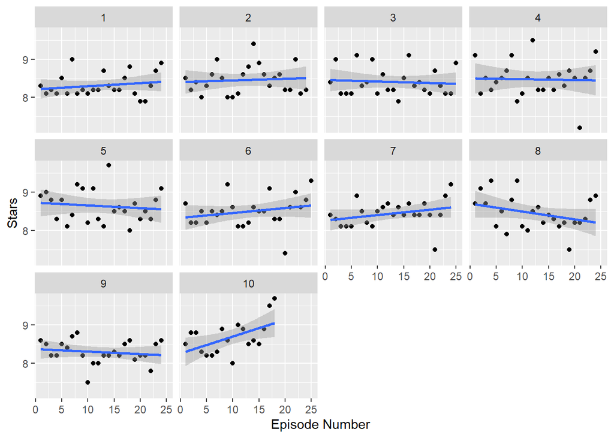

```r
ggplot(friends, aes(x=`Episode Number`,y=Stars)) + geom_point() + geom_smooth(method="lm")+facet_wrap(~ Season)
```

```r
lmod = lm(Stars ~ factor(Season)*`Episode Number`, friends)
anova(lmod)
```

```
## Analysis of Variance Table
##
## Response: Stars
##                                  Df Sum Sq Mean Sq F value  Pr(>F)
## factor(Season)                    9  2.905 0.32279  2.1858 0.02412 *
## `Episode Number`                  1  0.042 0.04171  0.2824 0.59565
## factor(Season):`Episode Number`   9  2.067 0.22967  1.5553 0.13036
## Residuals                       216 31.897 0.14767
## ---
## Signif. codes:  0 '***' 0.001 '**' 0.01 '*' 0.05 '.' 0.1 ' ' 1
```

The test concludes that there is no significant interaction. This means that trends cannot be distinguished between seasons. The anova function also determines whether the episode makes a difference. This is because the anova function compares pairs of models in a sequence. Since the p-value of the `Episode Number`, 0.59565, is not significant, the episode is not significant. I conclude that there is no evidence that the episode stars of friends varied with a consistent pattern within a season.

# Did any of the major directors have a significant impact on the ratings?

I have decided to classify a major director by having directed at least 10 episodes. Creating an indicator variable for each director.

```r
friends %>% mutate(Ben_Weiss = as.numeric(grepl("Ben Weiss",Director))) -> friends
friends %>% mutate(David_Schwimmer = as.numeric(grepl("David Schwimmer",Director))) -> friends
friends %>% mutate(Gail_Mancuso = as.numeric(grepl("Gail Mancuso",Director))) -> friends
friends %>% mutate(Gary_Halvorson = as.numeric(grepl("Gary Halvorson",Director))) -> friends
friends %>% mutate(James_Burrows= as.numeric(grepl("James Burrows",Director))) -> friends
friends %>% mutate(Kevin_Bright= as.numeric(grepl("Kevin Bright",Director))) -> friends
friends %>% mutate(Michael_Lembeck= as.numeric(grepl("Michael Lembeck",Director))) -> friends
friends %>% mutate(Peter_Bonerz= as.numeric(grepl("Peter Bonerz",Director))) -> friends
```

It could be a good idea to include a `Season` factor in the linear model, since if there was a general episode stars decline or increase over time, the `Season` variable would account for that. However, I discussed above that the episode ratings did not change significantly over time. This means that I shall use a simple linear model without the `Season` factor.

```r
Director_Indicator = friends %>% select(Stars, Ben_Weiss, David_Schwimmer,Gail_Mancuso,Gary_Halvorson,James_Burrows,Kevin_Bright,Michael_Lembeck,Peter_Bonerz) %>% pivot_longer(!Stars, names_to = "variable", values_to = "value")
Director_Indicator %>% split(.$variable) %>% map(~ lm(Stars ~ value, data = .)) %>% map_dfr(~ tidy(.)[2,],.id="Predictor")
```

```
## # A tibble: 8 x 6
##   Predictor       term  estimate std.error statistic   p.value
##   <chr>           <chr>    <dbl>     <dbl>     <dbl>     <dbl>
## 1 Ben_Weiss       value  -0.166     0.128     -1.30  0.196
## 2 David_Schwimmer value   0.0847    0.128      0.660 0.510
## 3 Gail_Mancuso    value  -0.108     0.109     -0.990 0.323
## 4 Gary_Halvorson  value  -0.0740    0.0614    -1.21  0.229
## 5 James_Burrows   value   0.0439    0.106      0.414 0.679
## 6 Kevin_Bright    value   0.243     0.0595     4.09  0.0000601
## 7 Michael_Lembeck value   0.0689    0.0854     0.807 0.420
## 8 Peter_Bonerz    value  -0.141     0.117     -1.20  0.230
```

It is clear that `Kevin_Bright` had a significant positive impact on the ratings of the show. Kevin Bright is one of the leading producers of Friends, and is a experienced director. This conclusion is valid in wider context.

# Are there any particulary well/low performing episodes?

We are looking for an episode which stands out (outlier). The best thing to find this episode is to create a model with `Stars` as the response and `Season` as the only predictor. We can use the diagnostic plots to scout any possible outliers.

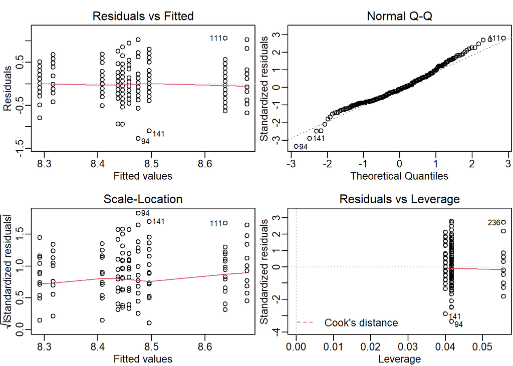

```r
lmod = lm(Stars ~ Season, friends)
diagnostic_plots(lmod)
```

Looking at the Normal Q-Q, there are a few points which stray from the line towards the upper and lower tail. However, they seem to have standardized residuals of less than 3.5 in absolute value. Since the Bonferroni Criterion tends to be more conservative than the nominal level approach, we expect to find no outliers. This is how you would apply the Bonferroni Criterion to find outliers, if they exist.

```r
#produces an array of TRUE/FALSE values on whether standerised residuals are higher or lower than Bonferroni Criterion
TrueFalseArray=(abs(rstudent(lmod)) > abs(qt(.05/((nrow(friends))*2) ,lmod$df.residual-1)))
#calculates the number of outliers
sum(TrueFalseArray, na.rm = TRUE)
```

```
## [1] 0
```

I conclude that there are no particularly well or low performing episodes at 5% significance level.

# Are there any episodes with an unusual ammount of votes?

The analysis and reasoning for this question is simular to the previous question. I am also going to apply the Bonferroni Criterion here to find outliers

```r
lmod = lm(Votes ~ Season, friends)
friends$Episode_Title[abs(rstudent(lmod)) > abs(qt(.05/((nrow(friends))*2) ,lmod$df.residual-1))]
```

```
## [1] The One Where Monica Gets a Roommate: The Pilot
## [2] The One Where Everybody Finds Out
## [3] The Last One: Part 2
## 236 Levels: The Last One: Part 1 The Last One: Part 2 ... The One Without the Ski Trip
```

There are 3 episodes with an unusual number of votes,

- The One Where Monica Gets a Roommate: The Pilot
- The One Where Everybody Finds Out
- The Last One: Part 2

Unsurprisingly, these are the three episodes with the largest number of votes in the entire series. ‘The One Where Monica Gets a Roommate: The Pilot’ is the first episode of season 1, and ‘The Last One: Part 2’ is the last episode of season 10. You would expect these episodes to have a large number of votes. ‘The One Where Everybody Finds Out’ has a very good plot and the highest rated episode of the series, so you would also expect this episode to have a large number of votes. There are no episodes with an unusually small number of votes.

# Summary and findings

This project was actually very interesting. Friends had extraordinarily positive ratings throughout it’s lifetime, which is very impressive considering many shows/sitcoms tend to peak and then drop off, such as The Big Bang Theory. Kevin Bright had a significant positive impact on the rating of each episode. There were a few episodes which had an extraordinary high number of votes. But there were no episodes which had a significantly high rating. The average rating for each season was 8-9 stars, with some episodes being rated 9.7. This is very high for IMDB!

It would be cool to explore a prediction type question, for example predicting the average star rating for a season 11, if it was produced. But a prediction test on this data would be difficult since the plot and synopsis of the show changes so much after the last episode of season 10. So the plots and the dynamic would be very different. There was a Joey based spin off show, but it was cancelled after star ratings plummeted.